# Basic statistics for health research - week 7, ex. 1

Benjamin Skov Kaas-Hansen

28/10/2021

### Prep and setup

```r
library(plyr) # must be loaded before dplyr (which is loaded with tidyverse)
library(tidyverse)
library(purrr)
library(lindia)

theme_set(theme_minimal())

#' @param m model object
#' returns a matrix
pretty_estimates <- function(m) {
    cbind(Est. = m$coefficients, confint(m))
}
```

# Cadmium (+ Q1)

```r
cad <- read_delim("http://publicifsv.sund.ku.dk/~lts/basal/data/cadmium.txt", delim = " ") %>%
    mutate(grp = factor(grp, levels = 1:3, labels = c("long_exposure", "short_exposure", "no_exposure")))
```

## Q2: Group-specific summaries

High-exposure individuals seems different (lower vital capacity, higher age), but not substantively so. Vital capacity decreases with age, so that’s a quite likely explanation.

```r
dlply(cad, "grp", summary)
```

```
## $long_exposure
##              grp          age            vitcap
##  long_exposure :12   Min.   :39.00   Min.   :2.700
##  short_exposure: 0   1st Qu.:41.00   1st Qu.:2.955
##  no_exposure   : 0   Median :48.00   Median :3.865
##                      Mean   :49.75   Mean   :3.949
##                      3rd Qu.:58.25   3rd Qu.:4.737
##                      Max.   :65.00   Max.   :5.520
##
## $short_exposure
##              grp          age            vitcap
##  long_exposure : 0   Min.   :21.00   Min.   :2.700
##  short_exposure:28   1st Qu.:29.75   1st Qu.:4.240
##  no_exposure   : 0   Median :38.00   Median :4.615
##                      Mean   :37.79   Mean   :4.472
##                      3rd Qu.:43.50   3rd Qu.:5.062
##                      Max.   :58.00   Max.   :5.220
##
## $no_exposure
##              grp          age           vitcap
##  long_exposure : 0   Min.   :18.0   Min.   :3.030
##  short_exposure: 0   1st Qu.:32.0   1st Qu.:4.010
##  no_exposure   :44   Median :41.0   Median :4.530
##                      Mean   :39.8   Mean   :4.462
##                      3rd Qu.:48.0   3rd Qu.:4.902
##                      Max.   :65.0   Max.   :5.860
##
## attr(,"split_type")
## [1] "data.frame"
## attr(,"split_labels")
##              grp
## 1  long_exposure
## 2 short_exposure
## 3    no_exposure
```

```r
# Alternative
split(cad, cad$grp) %>%
    map(summary)
```

```
## $long_exposure
##              grp          age            vitcap
##  long_exposure :12   Min.   :39.00   Min.   :2.700
##  short_exposure: 0   1st Qu.:41.00   1st Qu.:2.955
##  no_exposure   : 0   Median :48.00   Median :3.865
##                      Mean   :49.75   Mean   :3.949
##                      3rd Qu.:58.25   3rd Qu.:4.737
##                      Max.   :65.00   Max.   :5.520
##
## $short_exposure
##              grp          age            vitcap
##  long_exposure : 0   Min.   :21.00   Min.   :2.700
##  short_exposure:28   1st Qu.:29.75   1st Qu.:4.240
##  no_exposure   : 0   Median :38.00   Median :4.615
##                      Mean   :37.79   Mean   :4.472
##                      3rd Qu.:43.50   3rd Qu.:5.062
##                      Max.   :58.00   Max.   :5.220
##
## $no_exposure
##              grp          age           vitcap
##  long_exposure : 0   Min.   :18.0   Min.   :3.030
##  short_exposure: 0   1st Qu.:32.0   1st Qu.:4.010
##  no_exposure   :44   Median :41.0   Median :4.530
##                      Mean   :39.8   Mean   :4.462
##                      3rd Qu.:48.0   3rd Qu.:4.902
##                      Max.   :65.0   Max.   :5.860
```

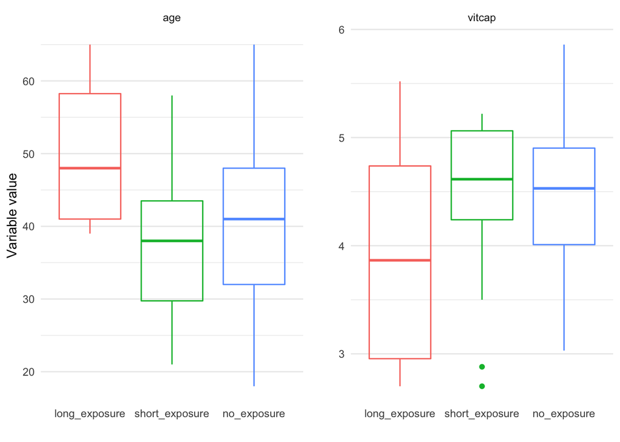

```r
cad %>%
    pivot_longer(-grp, names_to = "var", values_to = "value") %>%
    ggplot(aes(x = grp, y = value, colour = grp)) +
        geom_boxplot(position = "dodge2", fill = NA, show.legend = FALSE) +
        facet_wrap(~ var, scales = "free") +
        theme(panel.spacing = grid::unit(2, "lines"),
              panel.grid.major.x = element_blank()) +
        labs(x = "", y = "Variable value")
```

## Q3: Difference between vital capacity across the exposure groups?

```r
model1 <- lm(vitcap ~ grp, data = cad)
summary(model1)
```

```
##
## Call:
## lm(formula = vitcap ~ grp, data = cad)
##
## Residuals:
##      Min       1Q   Median       3Q      Max
## -1.77179 -0.45205  0.09808  0.51295  1.57083
##
## Coefficients:
##                   Estimate Std. Error t value Pr(>|t|)
## (Intercept)         3.9492     0.2149  18.376   <2e-16 ***
## grpshort_exposure   0.5226     0.2569   2.035   0.0452 *
## grpno_exposure      0.5129     0.2425   2.115   0.0375 *
## ---
## Signif. codes:  0 '***' 0.001 '**' 0.01 '*' 0.05 '.' 0.1 ' ' 1
##
## Residual standard error: 0.7445 on 81 degrees of freedom
## Multiple R-squared:  0.05767,    Adjusted R-squared:  0.0344
## F-statistic: 2.478 on 2 and 81 DF,  p-value: 0.09021
```

```r
round(pretty_estimates(model1), 2)
```

```
##                   Est. 2.5 % 97.5 %
## (Intercept)       3.95  3.52   4.38
## grpshort_exposure 0.52  0.01   1.03
## grpno_exposure    0.51  0.03   1.00
```

The F test has a p-value of 0.09 so not significant difference, but would you really rule it out entirely? Also because the p values for the coefficients from the two exposure groups are actually below 0.05. It’s important, however, to note that the CI’s for these confidence intervals are basically 0 to 1, so quite imprecise.

If we want to study the pairwise differences, we have to use Tukey-corrected T tests. That requires an analysis-of-variance, and running the Tukey multiple comparisons of means analysis we see that all CI’s contain 0 (although not by a large margin for short vs. long exposure and no vs. long exposure, which corresponds well to what we saw in the boxplots). Also note that the CI’s are now wider because we’ve corrected for multiple comparisons.

```r
model2 <- aov(vitcap ~ grp, data = cad)
TukeyHSD(model2)
```

```
##   Tukey multiple comparisons of means
##     95% family-wise confidence level
##
## Fit: aov(formula = vitcap ~ grp, data = cad)
##
## $grp
##                                     diff         lwr       upr     p adj
## short_exposure-long_exposure  0.52261905 -0.09066563 1.1359037 0.1104862
## no_exposure-long_exposure     0.51287879 -0.06598823 1.0917458 0.0930317
## no_exposure-short_exposure   -0.00974026 -0.43943758 0.4199571 0.9983865
```

### Diagnostic plots

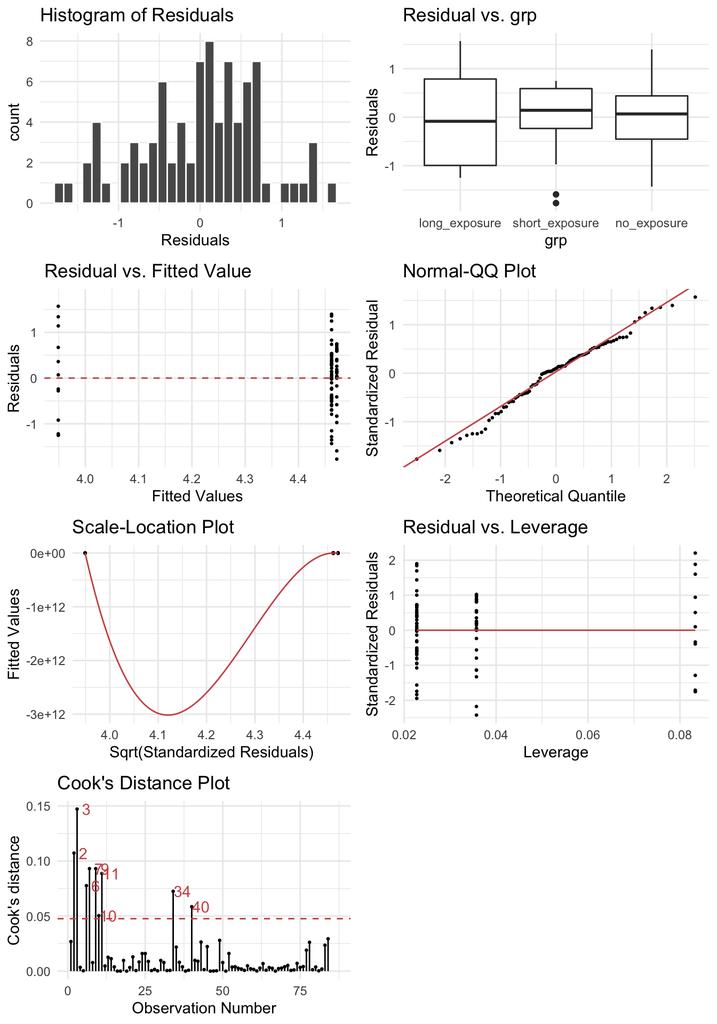

```r
gg_diagnose(model1)
```

```r
with(cad, bartlett.test(vitcap, grp)) # test of variance homogeneity
```

```
##
##  Bartlett test of homogeneity of variances
##
## data:  vitcap and grp
## Bartlett's K-squared = 3.7164, df = 2, p-value = 0.156
```

```r
kruskal.test(vitcap ~ grp, data = cad) # in case of violation of the assumption of normally-distributed residuals
```

```
##
##  Kruskal-Wallis rank sum test
##
## data:  vitcap by grp
## Kruskal-Wallis chi-squared = 2.7909, df = 2, p-value = 0.2477
```

## Q4: Correlation between vitcap and age within each group

I’ll do linear model instead of correlation test per se. The regression coefficients within each group might sugggest that vital capacity fall more rapidly in the long-term exposed individuals. Inteterstingly, the long-term exposed have higher vitcap when younger. Note also that ggplot2 doesn’t extrapolate the lines beyond the data, as base graphics in R do.

```r
fits <- list(overall = lm(vitcap ~ age, data = cad)) %>%
    c(dlply(cad, "grp", function(d) lm(vitcap ~ age, data = d)))

llply(fits, summary) # requires plyr
```

```
## $overall
##
## Call:
## lm(formula = vitcap ~ age, data = cad)
##
## Residuals:
##      Min       1Q   Median       3Q      Max
## -1.35136 -0.37332  0.02796  0.40735  1.42776
##
## Coefficients:
##              Estimate Std. Error t value Pr(>|t|)
## (Intercept)  6.033316   0.247487  24.378  < 2e-16 ***
## age         -0.040478   0.005881  -6.883 1.08e-09 ***
## ---
## Signif. codes:  0 '***' 0.001 '**' 0.01 '*' 0.05 '.' 0.1 ' ' 1
##
## Residual standard error: 0.6068 on 82 degrees of freedom
## Multiple R-squared:  0.3662, Adjusted R-squared:  0.3584
## F-statistic: 47.37 on 1 and 82 DF,  p-value: 1.082e-09
##
##
## $long_exposure
##
## Call:
## lm(formula = vitcap ~ age, data = d)
##
## Residuals:
##      Min       1Q   Median       3Q      Max
## -1.05767 -0.37933 -0.05867  0.50883  1.07700
##
## Coefficients:
##             Estimate Std. Error t value Pr(>|t|)
## (Intercept)  8.18344    1.19787   6.832 4.56e-05 ***
## age         -0.08511    0.02372  -3.589  0.00494 **
## ---
## Signif. codes:  0 '***' 0.001 '**' 0.01 '*' 0.05 '.' 0.1 ' ' 1
##
## Residual standard error: 0.7163 on 10 degrees of freedom
## Multiple R-squared:  0.5629, Adjusted R-squared:  0.5192
## F-statistic: 12.88 on 1 and 10 DF,  p-value: 0.00494
```

[output cut: 27 more lines]

```
##
## Residuals:
##     Min      1Q  Median      3Q     Max
## -1.2450 -0.4264 -0.0118  0.4527  1.1395
##
## Coefficients:
##             Estimate Std. Error t value Pr(>|t|)
## (Intercept)  5.68029    0.31313   18.14  < 2e-16 ***
## age         -0.03061    0.00754   -4.06 0.000209 ***
## ---
## Signif. codes:  0 '***' 0.001 '**' 0.01 '*' 0.05 '.' 0.1 ' ' 1
##
## Residual standard error: 0.5936 on 42 degrees of freedom
## Multiple R-squared:  0.2818, Adjusted R-squared:  0.2647
## F-statistic: 16.48 on 1 and 42 DF,  p-value: 0.0002095
```

```r
map(fits, summary) # alternative with purrr
```

```
## $overall
##
## Call:
## lm(formula = vitcap ~ age, data = cad)
##
## Residuals:
##      Min       1Q   Median       3Q      Max
## -1.35136 -0.37332  0.02796  0.40735  1.42776
##
## Coefficients:
##              Estimate Std. Error t value Pr(>|t|)
## (Intercept)  6.033316   0.247487  24.378  < 2e-16 ***
## age         -0.040478   0.005881  -6.883 1.08e-09 ***
## ---
## Signif. codes:  0 '***' 0.001 '**' 0.01 '*' 0.05 '.' 0.1 ' ' 1
##
## Residual standard error: 0.6068 on 82 degrees of freedom
## Multiple R-squared:  0.3662, Adjusted R-squared:  0.3584
## F-statistic: 47.37 on 1 and 82 DF,  p-value: 1.082e-09
##
##
## $long_exposure
##
## Call:
## lm(formula = vitcap ~ age, data = d)
##
## Residuals:
##      Min       1Q   Median       3Q      Max
## -1.05767 -0.37933 -0.05867  0.50883  1.07700
##
## Coefficients:
##             Estimate Std. Error t value Pr(>|t|)
## (Intercept)  8.18344    1.19787   6.832 4.56e-05 ***
## age         -0.08511    0.02372  -3.589  0.00494 **
## ---
## Signif. codes:  0 '***' 0.001 '**' 0.01 '*' 0.05 '.' 0.1 ' ' 1
##
## Residual standard error: 0.7163 on 10 degrees of freedom
## Multiple R-squared:  0.5629, Adjusted R-squared:  0.5192
## F-statistic: 12.88 on 1 and 10 DF,  p-value: 0.00494
```

[output cut: 27 more lines]

```
##
## Residuals:
##     Min      1Q  Median      3Q     Max
## -1.2450 -0.4264 -0.0118  0.4527  1.1395
##
## Coefficients:
##             Estimate Std. Error t value Pr(>|t|)
## (Intercept)  5.68029    0.31313   18.14  < 2e-16 ***
## age         -0.03061    0.00754   -4.06 0.000209 ***
## ---
## Signif. codes:  0 '***' 0.001 '**' 0.01 '*' 0.05 '.' 0.1 ' ' 1
##
## Residual standard error: 0.5936 on 42 degrees of freedom
## Multiple R-squared:  0.2818, Adjusted R-squared:  0.2647
## F-statistic: 16.48 on 1 and 42 DF,  p-value: 0.0002095
```

```r
llply(fits, pretty_estimates) # requires plyr
```

```
## $overall
##                    Est.       2.5 %      97.5 %
## (Intercept)  6.03331620  5.54098564  6.52564676
## age         -0.04047814 -0.05217758 -0.02877871
##
## $long_exposure
##                    Est.      2.5 %      97.5 %
## (Intercept)  8.18343838  5.5144219 10.85245487
## age         -0.08511099 -0.1379542 -0.03226781
##
## $short_exposure
##                    Est.       2.5 %      97.5 %
## (Intercept)  6.23003098  5.32607562  7.13398633
## age         -0.04653201 -0.06980013 -0.02326389
##
## $no_exposure
##                    Est.       2.5 %      97.5 %
## (Intercept)  5.68029060  5.04835847  6.31222274
## age         -0.03061267 -0.04582991 -0.01539543
```

```r
map(fits, pretty_estimates) # alternative with purrr
```

```
## $overall
##                    Est.       2.5 %      97.5 %
## (Intercept)  6.03331620  5.54098564  6.52564676
## age         -0.04047814 -0.05217758 -0.02877871
##
## $long_exposure
##                    Est.      2.5 %      97.5 %
## (Intercept)  8.18343838  5.5144219 10.85245487
## age         -0.08511099 -0.1379542 -0.03226781
##
## $short_exposure
##                    Est.       2.5 %      97.5 %
## (Intercept)  6.23003098  5.32607562  7.13398633
## age         -0.04653201 -0.06980013 -0.02326389
##
## $no_exposure
##                    Est.       2.5 %      97.5 %
## (Intercept)  5.68029060  5.04835847  6.31222274
## age         -0.03061267 -0.04582991 -0.01539543
```

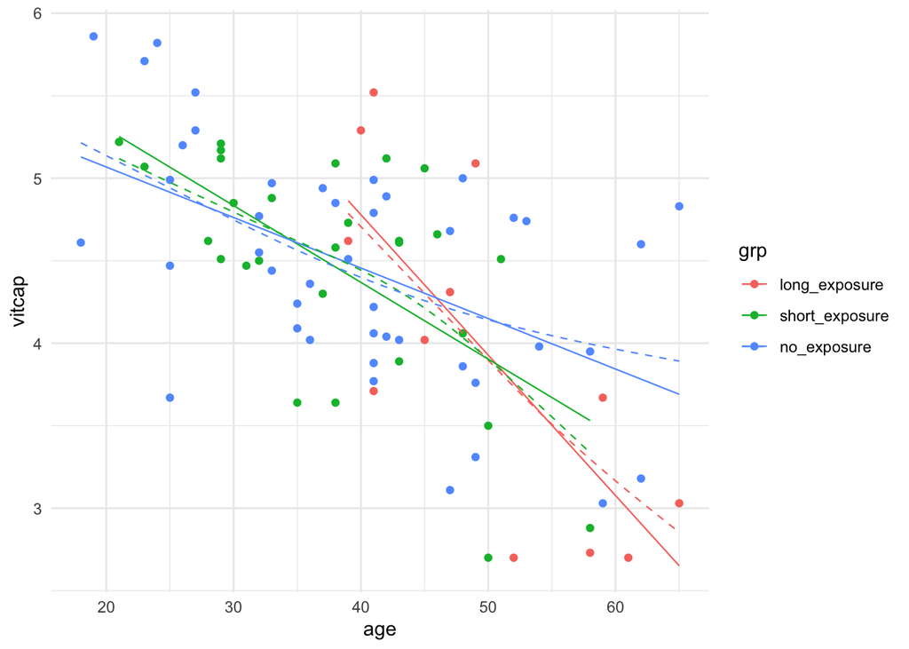

```r
ggplot(cad, aes(age, vitcap, colour = grp)) +
    geom_point() +
    geom_smooth(method = "lm", formula = y ~ x, se = FALSE, size = 0.4) +
    geom_smooth(method = "gam", formula = y ~ s(x, bs = "cs"), se = FALSE, linetype = 2, size = 0.4)
```

The plot clearly shows that the vital capacity decreases more rapidly in long-term exposed individuals compared to the others. Also, the not exposed have the slowest deterioration. The GAM lines above are not very different from the straight lines.

## Q6: Provide estimate for the difference between 40-year old long-term exposed individuals and 40-year old non-exposed

```r
cad <- cad %>%
    mutate(age_around_40 = age - 40)
model3 <- lm(vitcap ~ age_around_40 * grp, data = cad)
# model3 <- lm(vitcap ~ I(age - 40) * grp, data = cad) # alternative, but gives ugly coefficient names
summary(model3)
```

```
##
## Call:
## lm(formula = vitcap ~ age_around_40 * grp, data = cad)
##
## Residuals:
##      Min       1Q   Median       3Q      Max
## -1.24497 -0.36929  0.01977  0.43681  1.13953
##
## Coefficients:
##                                 Estimate Std. Error t value Pr(>|t|)
## (Intercept)                      4.77900    0.25730  18.573  < 2e-16 ***
## age_around_40                   -0.08511    0.01967  -4.327 4.44e-05 ***
## grpshort_exposure               -0.41025    0.28208  -1.454   0.1499
## grpno_exposure                  -0.32322    0.27245  -1.186   0.2391
## age_around_40:grpshort_exposure  0.03858    0.02327   1.658   0.1014
## age_around_40:grpno_exposure     0.05450    0.02107   2.587   0.0116 *
## ---
## Signif. codes:  0 '***' 0.001 '**' 0.01 '*' 0.05 '.' 0.1 ' ' 1
##
## Residual standard error: 0.5942 on 78 degrees of freedom
## Multiple R-squared:  0.422,  Adjusted R-squared:  0.385
## F-statistic: 11.39 on 5 and 78 DF,  p-value: 2.871e-08
```

```r
pretty_estimates(model3)
```

```
##                                        Est.        2.5 %      97.5 %
## (Intercept)                      4.77899881  4.266749088  5.29124854
## age_around_40                   -0.08511099 -0.124274163 -0.04594782
## grpshort_exposure               -0.41024826 -0.971831138  0.15133461
## grpno_exposure                  -0.32321504 -0.865624925  0.21919484
## age_around_40:grpshort_exposure  0.03857898 -0.007753455  0.08491141
## age_around_40:grpno_exposure     0.05449832  0.012551569  0.09644507
```

```r
anova(model3) # shows significant interaction, so it should stay in the model
```

```
## Analysis of Variance Table
##
## Response: vitcap
##                   Df  Sum Sq Mean Sq F value    Pr(>F)
## age_around_40      1 17.4446 17.4446 49.4159 6.918e-10 ***
## grp                2  0.1617  0.0808  0.2290   0.79584
## age_around_40:grp  2  2.4995  1.2497  3.5402   0.03376 *
## Residuals         78 27.5352  0.3530
## ---
## Signif. codes:  0 '***' 0.001 '**' 0.01 '*' 0.05 '.' 0.1 ' ' 1
```

```r
# Difference between estimates from two models
bind_cols(model = c("Only group as covariate", "Interaction b/w age and grp"),
          bind_rows(pretty_estimates(model3)[4, ], pretty_estimates(model1)[3, ]))
```

```
## # A tibble: 2 × 4
##   model                         Est. `2.5 %` `97.5 %`
##   <chr>                        <dbl>   <dbl>    <dbl>
## 1 Only group as covariate     -0.323 -0.866     0.219
## 2 Interaction b/w age and grp  0.513  0.0305    0.995
```

## Q7: How many more years does it take to lose 1 litre of vital capacity when one is non-exposed compared with long-term exposed?

We just want a point estimate, so use the slope (unit: liters lost per year) and use the reciprocal to get years to one liter. We are looking for the difference between these two values (approx. 20.9 years)

```r
1/model3$coefficients["age_around_40"]
```

```
## age_around_40
##     -11.74936
```

```r
1/(model3$coefficients["age_around_40"] + model3$coefficients["age_around_40:grpno_exposure"]) # = 1/0.03061
```

```
## age_around_40
##     -32.66621
```